# Linear modeling and `broom`

## Tests

### correlation

Correlation gives you the direction and strength of the linear association between two numeric variables. What can you use it to test?

- Is the expression of this gene associated with the expression of another gene?
- Is the expression of this gene associated with the dose of the drug?
- Is the level of this molecule associated with a disease state?

#### Plot first

Before deciding whether to test something, you should always plot first! Visualizing the variables helps you decided what test/action to take next.

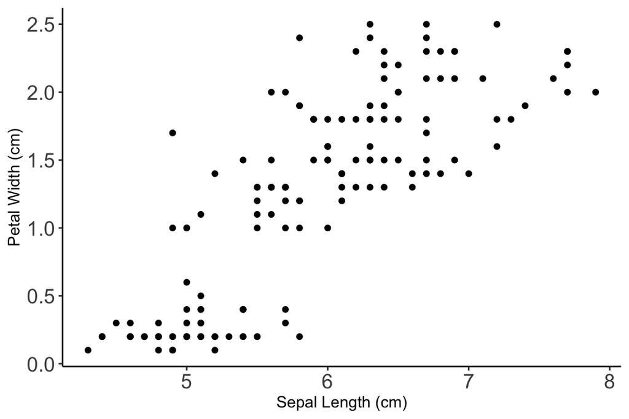

```r
ggplot(iris, aes(x = Sepal.Length, y = Petal.Width)) +
  geom_point() +
  labs(x = 'Sepal Length (cm)', y = 'Petal Width (cm)') +
  theme_classic() +
  theme(axis.text = element_text(size = 14))
```

The variables look linearly related, so calculating the correlation between them might tell us something.

#### `cor()`

`cor()` gives you the correlation (the r value) between two numeric values.

```r
# correlated
cor(iris$Sepal.Length, iris$Petal.Width)
```

```
## [1] 0.8179411
```

```r
# not correlated
cor(iris$Sepal.Length, iris$Sepal.Width)
```

```
## [1] -0.1175698
```

#### Side note: the `%$%` pipe

Remember how some tests we couldn’t pipe into? The solution is the `%$%` pipe!!! Basically, behind the scenes it translates the column names to base R, so functions can take them. It’s in the magrittr package (which is installed along with the tidyverse), so you have to load the library before using the `%$%` pipe. The library is in the setup chunk at the top of the document, so if you haven’t already, make sure to run that chunk before continuing

```r
# tidy t test example
iris %$% t.test(Sepal.Length, Petal.Width) %>% tidy()
```

```
## # A tibble: 1 x 10
##   estimate estimate1 estimate2 statistic   p.value parameter conf.low
##      <dbl>     <dbl>     <dbl>     <dbl>     <dbl>     <dbl>    <dbl>
## 1     4.64      5.84      1.20      50.5 1.36e-147      296.     4.46
## # ... with 3 more variables: conf.high <dbl>, method <chr>,
## #   alternative <chr>
```

```r
# and use it to pipe into cor()
iris %$% cor(Sepal.Length, Petal.Width)
```

```
## [1] 0.8179411
```

#### `cor.test()`

Similar to a t test, there’s a correlation test. In addition to giving you the correlation between two variables, it gives you a p-value, confidence interval, and a few other statistics.

```r
# correlated
cor.test(iris$Sepal.Length, iris$Petal.Width)
```

```
##
##  Pearson's product-moment correlation
##
## data:  iris$Sepal.Length and iris$Petal.Width
## t = 17.296, df = 148, p-value < 2.2e-16
## alternative hypothesis: true correlation is not equal to 0
## 95 percent confidence interval:
##  0.7568971 0.8648361
## sample estimates:
##       cor
## 0.8179411
```

```r
# not correlated
cor.test(iris$Sepal.Length, iris$Sepal.Width)
```

```
##
##  Pearson's product-moment correlation
##
## data:  iris$Sepal.Length and iris$Sepal.Width
## t = -1.4403, df = 148, p-value = 0.1519
## alternative hypothesis: true correlation is not equal to 0
## 95 percent confidence interval:
##  -0.27269325  0.04351158
## sample estimates:
##        cor
## -0.1175698
```

```r
# tidy
iris %$% cor.test(Sepal.Length, Petal.Width) %>% tidy()
```

```
## # A tibble: 1 x 8
##   estimate statistic  p.value parameter conf.low conf.high method
##      <dbl>     <dbl>    <dbl>     <int>    <dbl>     <dbl> <chr>
## 1    0.818      17.3 2.33e-37       148    0.757     0.865 Pears…
## # ... with 1 more variable: alternative <chr>
```

### linear model / linear regression

Linear regression attempts to model the relationship between two variables by fitting a linear equation to observed data (by minimizing residuals). Then you use can use it for making further predictions.

#### Plot first

Before deciding whether to test something, you should always plot first! Visualizing the variables helps you decided what test/action to take next.

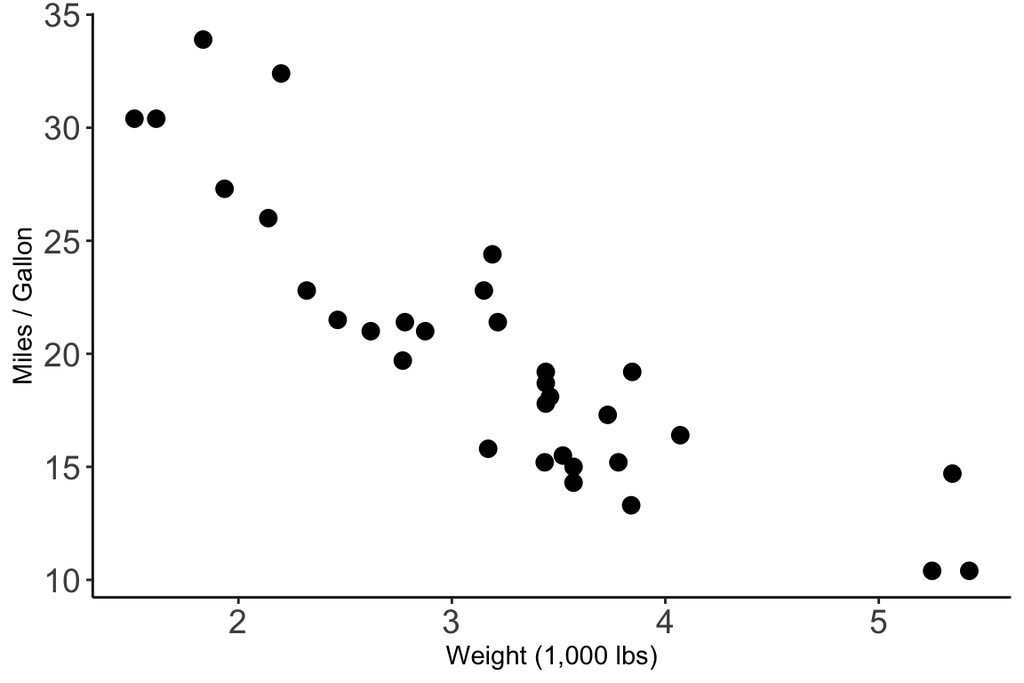

```r
ggplot(mtcars, aes(x = wt, y = mpg)) +
  geom_point(size = 3) +
  labs(x = 'Weight (1,000 lbs)', y = 'Miles / Gallon') +
  theme_classic() +
  theme(axis.text = element_text(size = 14))
```

Again, the variables appear linearly related, so a linear model might be interesting here.

#### model

`lm()` calculates the linear regression/linear model/line of best fit. It gives you the slope and y-intercept of the lines, the error, the test statistic, and the p-value

```r
lm(mpg ~ wt, data = mtcars) %>% tidy()
```

```
## # A tibble: 2 x 5
##   term        estimate std.error statistic  p.value
##   <chr>          <dbl>     <dbl>     <dbl>    <dbl>
## 1 (Intercept)    37.3      1.88      19.9  8.24e-19
## 2 wt             -5.34     0.559     -9.56 1.29e-10
```

```r
# can pipe into lm()
mtcars %>% lm(mpg ~ wt, data = .) %>% tidy()
```

```
## # A tibble: 2 x 5
##   term        estimate std.error statistic  p.value
##   <chr>          <dbl>     <dbl>     <dbl>    <dbl>
## 1 (Intercept)    37.3      1.88      19.9  8.24e-19
## 2 wt             -5.34     0.559     -9.56 1.29e-10
```

#### plot again

Now, you can add the regression line to the scatterplot.

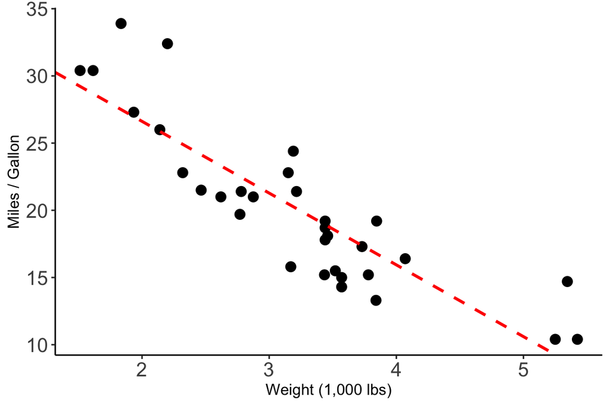

```r
ggplot(mtcars, aes(x = wt, y = mpg)) +
  geom_point(size = 3) +
  geom_abline(slope = -5.34, intercept = 37.3, linetype = 'dashed', size = 1, color = 'red') +
  labs(x = 'Weight (1,000 lbs)', y = 'Miles / Gallon') +
  theme_classic() +
  theme(axis.text = element_text(size = 14))
```

#### predict

You can use the slope and intercept from the regression line to make predictions. For example, what mpg would a car weighing 2,500 lbs have?

```r
2.5 * -5.34 + 37.3
```

```
## [1] 23.95
```

### ANOVA

#### Plot first

Before deciding whether to test something, you should always plot first! Visualizing the variables helps you decided what test/action to take next.

[figure not shown]

```r
ggplot(iris, aes(x = Sepal.Width, y = Sepal.Length)) +
  geom_point(size = 3) +
  labs(x = 'Sepal Length (cm)', y = 'Sepal Width (cm)') +
  theme_classic() +
  theme(axis.text = element_text(size = 14))
```

Sometimes it doesn’t look interesting at first and you need to plot multiple times.

[figure not shown]

```r
# with color by species
ggplot(iris, aes(x = Sepal.Width, y = Sepal.Length, color = Species)) +
  geom_point(size = 3) +
  labs(x = 'Sepal Length (cm)', y = 'Sepal Width (cm)') +
  theme_classic() +
  theme(axis.text = element_text(size = 14))
```

#### test

Analysis of variance (ANOVA) is (almost) the same as a pairwise t test; it compares means among three or more groups, but minimizes the error due to multiple testing. Use `aov()` for an ANOVA

```r
aov(Sepal.Length ~ Species, data = iris) %>% tidy()
```

```
## # A tibble: 2 x 6
##   term         df sumsq meansq statistic   p.value
##   <chr>     <dbl> <dbl>  <dbl>     <dbl>     <dbl>
## 1 Species       2  63.2 31.6        119.  1.67e-31
## 2 Residuals   147  39.0  0.265       NA  NA
```

#### `TukeyHSD()`

Just knowing that there is a difference between species isn’t super interesting, so after ANOVA, you can use a Tukey test for pairwise comparisons of the groups using `TukeyHSD()`

```r
aov(Sepal.Length ~ Species, data = iris) %>% TukeyHSD() %>% tidy()
```

```
## # A tibble: 3 x 6
##   term    comparison           estimate conf.low conf.high adj.p.value
##   <chr>   <chr>                   <dbl>    <dbl>     <dbl>       <dbl>
## 1 Species versicolor-setosa       0.93     0.686     1.17     3.39e-14
## 2 Species virginica-setosa        1.58     1.34      1.83     3.00e-15
## 3 Species virginica-versicolor    0.652    0.408     0.896    8.29e- 9
```

```r
flights
```

```
## # A tibble: 336,776 x 19
##     year month   day dep_time sched_dep_time dep_delay arr_time
##    <int> <int> <int>    <int>          <int>     <dbl>    <int>
##  1  2013     1     1      517            515         2      830
##  2  2013     1     1      533            529         4      850
##  3  2013     1     1      542            540         2      923
##  4  2013     1     1      544            545        -1     1004
##  5  2013     1     1      554            600        -6      812
##  6  2013     1     1      554            558        -4      740
##  7  2013     1     1      555            600        -5      913
##  8  2013     1     1      557            600        -3      709
##  9  2013     1     1      557            600        -3      838
## 10  2013     1     1      558            600        -2      753
## # ... with 336,766 more rows, and 12 more variables: sched_arr_time <int>,
## #   arr_delay <dbl>, carrier <chr>, flight <int>, tailnum <chr>,
## #   origin <chr>, dest <chr>, air_time <dbl>, distance <dbl>, hour <dbl>,
## #   minute <dbl>, time_hour <dttm>
```

```r
#aov(dep_time ~ month, data = flights) %>% TukeyHSD()
```

```r
# as.factor()
aov(dep_time ~ as.factor(month), data = flights) %>% TukeyHSD() %>% tidy()
```

```
## # A tibble: 66 x 6
##    term             comparison estimate conf.low conf.high adj.p.value
##    <chr>            <chr>         <dbl>    <dbl>     <dbl>       <dbl>
##  1 as.factor(month) 2-1           0.365   -13.9     14.6        1
##  2 as.factor(month) 3-1          12.3      -1.39    26.0        0.128
##  3 as.factor(month) 4-1           6.06     -7.66    19.8        0.955
##  4 as.factor(month) 5-1           3.96     -9.69    17.6        0.999
##  5 as.factor(month) 6-1           3.63    -10.1     17.4        0.999
##  6 as.factor(month) 7-1           5.95     -7.67    19.6        0.958
##  7 as.factor(month) 8-1           3.03    -10.6     16.6        1.000
##  8 as.factor(month) 9-1         -13.1     -26.9      0.683      0.0808
##  9 as.factor(month) 10-1         -7.10    -20.7      6.50       0.866
## 10 as.factor(month) 11-1         -2.78    -16.6     11.0        1.000
## # ... with 56 more rows
```

```r
# as.character()
aov(dep_time ~ as.character(month), data = flights) %>% TukeyHSD() %>% tidy()
```

```
## # A tibble: 66 x 6
##    term                comparison estimate conf.low conf.high adj.p.value
##    <chr>               <chr>         <dbl>    <dbl>     <dbl>       <dbl>
##  1 as.character(month) 10-1         -7.10    -20.7       6.50       0.866
##  2 as.character(month) 11-1         -2.78    -16.6      11.0        1.000
##  3 as.character(month) 12-1          9.98     -3.80     23.8        0.429
##  4 as.character(month) 2-1           0.365   -13.9      14.6        1
##  5 as.character(month) 3-1          12.3      -1.39     26.0        0.128
##  6 as.character(month) 4-1           6.06     -7.66     19.8        0.955
##  7 as.character(month) 5-1           3.96     -9.69     17.6        0.999
##  8 as.character(month) 6-1           3.63    -10.1      17.4        0.999
##  9 as.character(month) 7-1           5.95     -7.67     19.6        0.958
## 10 as.character(month) 8-1           3.03    -10.6      16.6        1.000
## # ... with 56 more rows
```

## `broom`

The `broom` package is for tidying up base R statistical tests and models. We’ve touched on the `tidy()` function from the package before, but it has two more useful functions.

### `glance()`

`glance()` gives you the model parameters. For the most part, you don’t need to worry about these (but it’s nice to known how to get them easily if you need them)

```r
aov(Sepal.Length ~ Species, data = iris) %>% glance()
```

```
## # A tibble: 1 x 11
##   r.squared adj.r.squared sigma statistic  p.value    df logLik   AIC   BIC
## *     <dbl>         <dbl> <dbl>     <dbl>    <dbl> <int>  <dbl> <dbl> <dbl>
## 1     0.619         0.614 0.515      119. 1.67e-31     3  -112.  231.  243.
## # ... with 2 more variables: deviance <dbl>, df.residual <int>
```

Sometimes `tidy()` and `glance()` give the same output

```r
# t test
t.test(extra ~ group, data = sleep) %>% tidy()
```

```
## # A tibble: 1 x 10
##   estimate estimate1 estimate2 statistic p.value parameter conf.low
##      <dbl>     <dbl>     <dbl>     <dbl>   <dbl>     <dbl>    <dbl>
## 1    -1.58      0.75      2.33     -1.86  0.0794      17.8    -3.37
## # ... with 3 more variables: conf.high <dbl>, method <chr>,
## #   alternative <chr>
```

```r
t.test(extra ~ group, data = sleep) %>% glance()
```

```
## # A tibble: 1 x 10
##   estimate estimate1 estimate2 statistic p.value parameter conf.low
##      <dbl>     <dbl>     <dbl>     <dbl>   <dbl>     <dbl>    <dbl>
## 1    -1.58      0.75      2.33     -1.86  0.0794      17.8    -3.37
## # ... with 3 more variables: conf.high <dbl>, method <chr>,
## #   alternative <chr>
```

### `augment()`

`augment()` adds information from your test/model back to a data table

```r
lm(Sepal.Width ~ Species, data = iris) %>% augment(iris) -> iris_lm

iris_lm
```

```
## # A tibble: 150 x 12
##    Sepal.Length Sepal.Width Petal.Length Petal.Width Species .fitted
##  *        <dbl>       <dbl>        <dbl>       <dbl> <fct>     <dbl>
##  1          5.1         3.5          1.4         0.2 setosa     3.43
##  2          4.9         3            1.4         0.2 setosa     3.43
##  3          4.7         3.2          1.3         0.2 setosa     3.43
##  4          4.6         3.1          1.5         0.2 setosa     3.43
##  5          5           3.6          1.4         0.2 setosa     3.43
##  6          5.4         3.9          1.7         0.4 setosa     3.43
##  7          4.6         3.4          1.4         0.3 setosa     3.43
##  8          5           3.4          1.5         0.2 setosa     3.43
##  9          4.4         2.9          1.4         0.2 setosa     3.43
## 10          4.9         3.1          1.5         0.1 setosa     3.43
## # ... with 140 more rows, and 6 more variables: .se.fit <dbl>,
## #   .resid <dbl>, .hat <dbl>, .sigma <dbl>, .cooksd <dbl>,
## #   .std.resid <dbl>
```

You can then do something with the original data and the model parameters together.

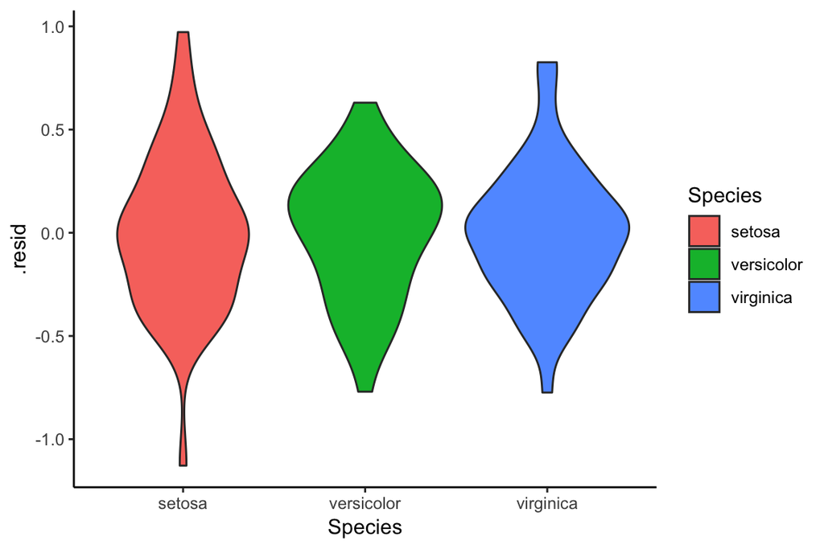

```r
ggplot(iris_lm, aes(x = Species, y = .resid, fill = Species)) +
  geom_violin() +
  theme_classic()
```